# Project 2 Outliers and Transformation

Andrew Jowe

# A.1 INTRODUCTION

In this statistical report, we explore the variance in wing length among three species of hawks: Cooper’s (CH), Red-tailed (RT), and Sharp-shinned (SS). The primary objective is to understand how the wing length, in millimeters, differs across these species. For our analysis, the distribution of the data has to be normal and the variance has to be constant to meet one of the assumptions of our Analysis of Variance (ANOVA) model. We will attempt to find the best combination of outlier removal and transformation to meet this assumption.

# B.1 INITIAL DATA PLOTTING

For this study, we will fit the data using the single-factor ANOVA (SFA) group means model which assesses the relationship between the hawk’s average primary wing feather length in $\mu_i$ vs the three species (where i = CH, RT, SS). This model follows where $Y_{ij}$ is the unknown population’s mean length of feather wing length for each hawk species plus individual error is $Y_{ij} = \mu_i + \epsilon_{ij}$.

For this model, we must satisfy assumptions of normality, constant variance, and group mean independence.

## B.1.1 Determining $\alpha$ for our testing

To determine which $\alpha$ to use for diagnostics, we need to assess whether we want to minimize the chance of a Type I Error or a Type II Error.

- Type I Error: When you reject $H_0$ when in reality $H_0$ is true. In this case, this represents the chance we conclude the data violates our ANOVA assumptions when in reality it satisfies our ANOVA assumptions.
- Type II Error: When you accept $H_0$ when in reality $H_0$ is false. In this case, this represents the chance we conclude the data satisfies our ANOVA assumptions when in reality it violates our ANOVA assumptions

For determining normality and constant variance, we want to minimize our probability of incorrect assumptions, so a Type II error is worse than a Type I error. As a result, we want to maximize $\alpha$, so we will use $\alpha = 0.1$ as our threshold.

## B.1.2 Original Data Overview

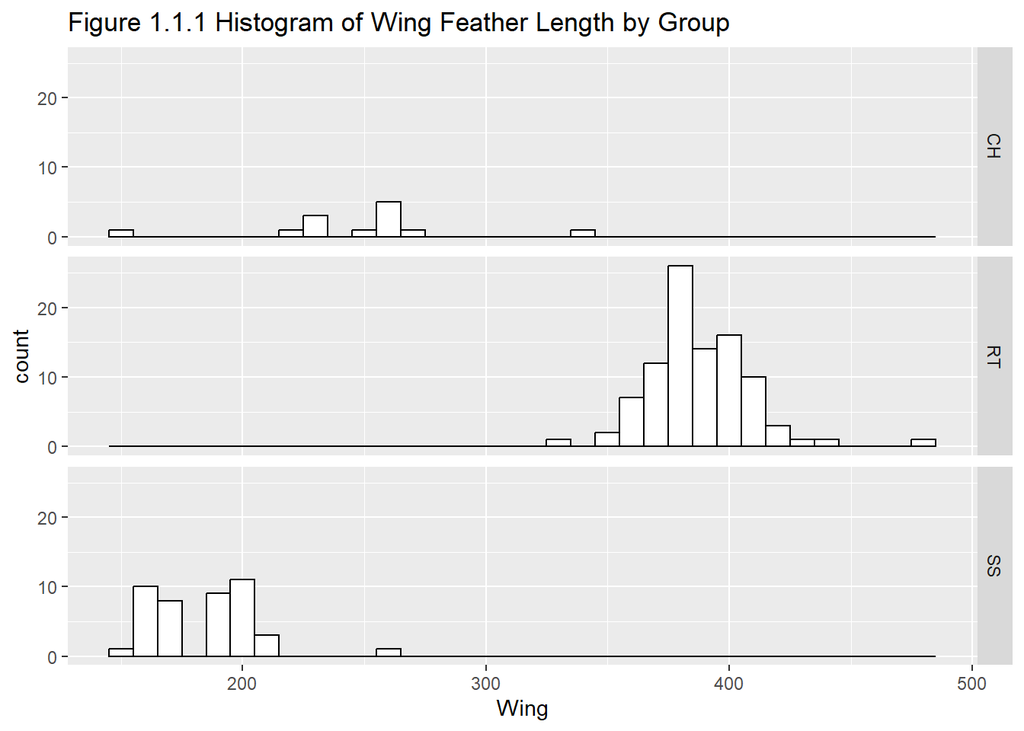

We will first assess normality and check if our data does not violate this assumption. We can briefly observe our data using histograms of wing feather length by group and looking at the curve. Figure 1.1.1 shows histograms that show the distribution of hawk feather length by species. It suggests that the normality assumption may be violated for the Cooper’s and Sharp-Shinned Hawks. However, for the Red-tailed Hawks, the data looks approximately normal.

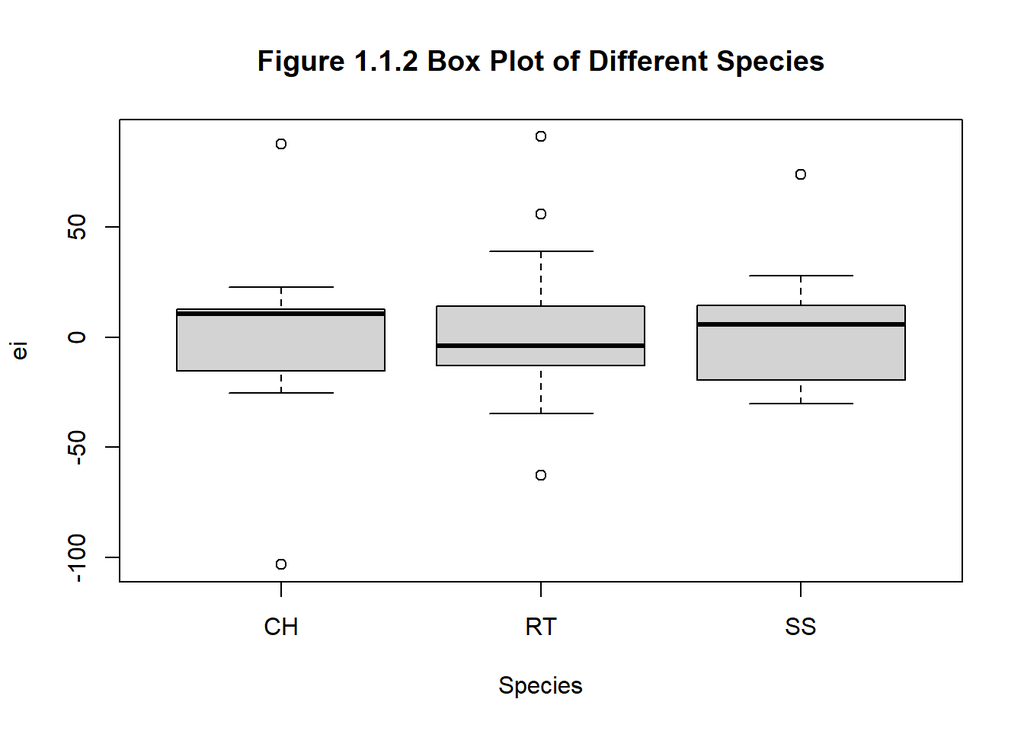

We will now assess outliers and variance. Figure 1.1.2 shows that we have outliers. These outliers can affect our normality distribution and variance of our groups. While our variances appear approximately constant in this figure, this may not be the case due to the outliers. We cannot conclude without doing formal testing.

## B.1.2 Normality of data

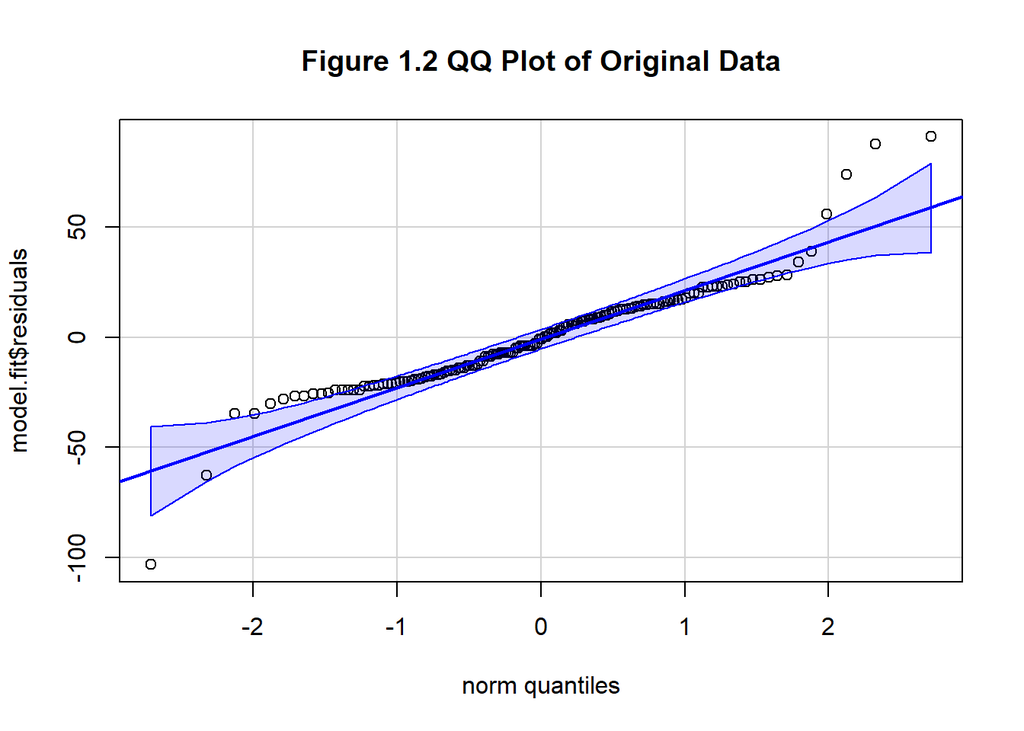

We can also speculate our normality assumption by fitting our model into a QQ plot that compares the quantiles of residuals against the quantiles of a normal theoretical distribution. Figure 1.2 shows the QQ plot as a “non-normal” plot with small and large outliers. This is not a conclusive test, so we will run the Shapiro-Wilks test as a formal test.

We use the Shapiro-Wilks test in R to quantitatively assess the normality of our model. Our null hypothesis is that the residuals of our data are normally distributed. Our alternative hypothesis is that they are not normally distributed. We got a p-value of $0$, and this value is less than a significance value of 0.1. Therefore, we reject the null hypothesis and conclude that the values of the residuals are non-normal. This test allows us to claim that the original data is not normally distributed.

## B.1.3 Constant Variance

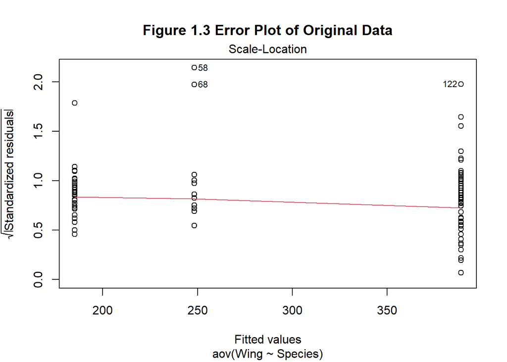

# C Outlier Removal and Transformation

We will consider all possible box cox transformations and outlier removal techniques to better fit our model.

## C.1 Transformation Possibilities

We will consider the following box-cox transformations:

1. PPCC
2. Shapiro-Wilks
3. Log-Likelihood

## C.1.1 No outlier removal, PPCC Transformation

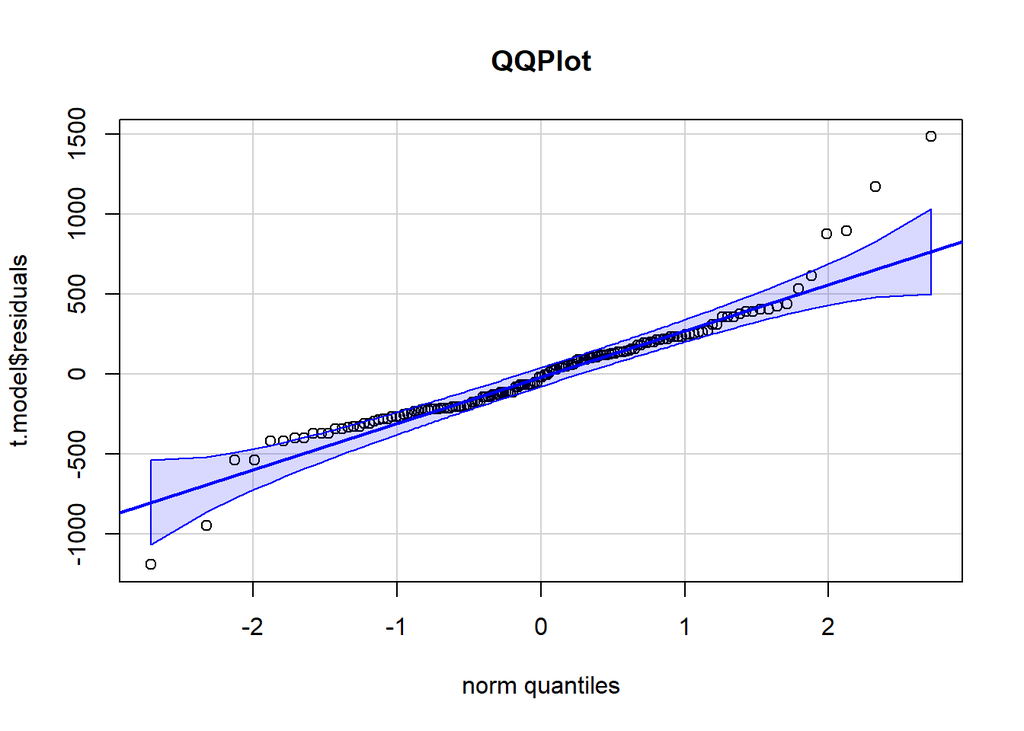

## Plot variances

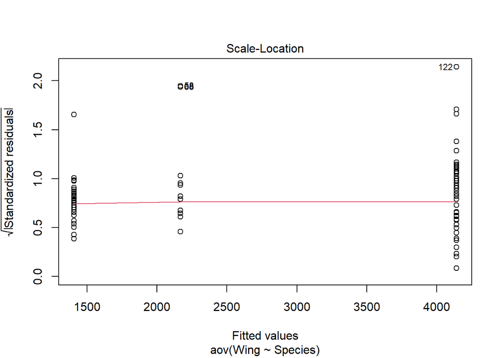

# No outlier removal, Log Likelihood Transformation

```
##              Df    Sum Sq   Mean Sq F value Pr(>F)
## Species       2 1.088e+11 5.440e+10   956.7 <2e-16 ***
## Residuals   147 8.358e+09 5.686e+07
## ---
## Signif. codes:  0 '***' 0.001 '**' 0.01 '*' 0.05 '.' 0.1 ' ' 1
```

## Get QQ Plot

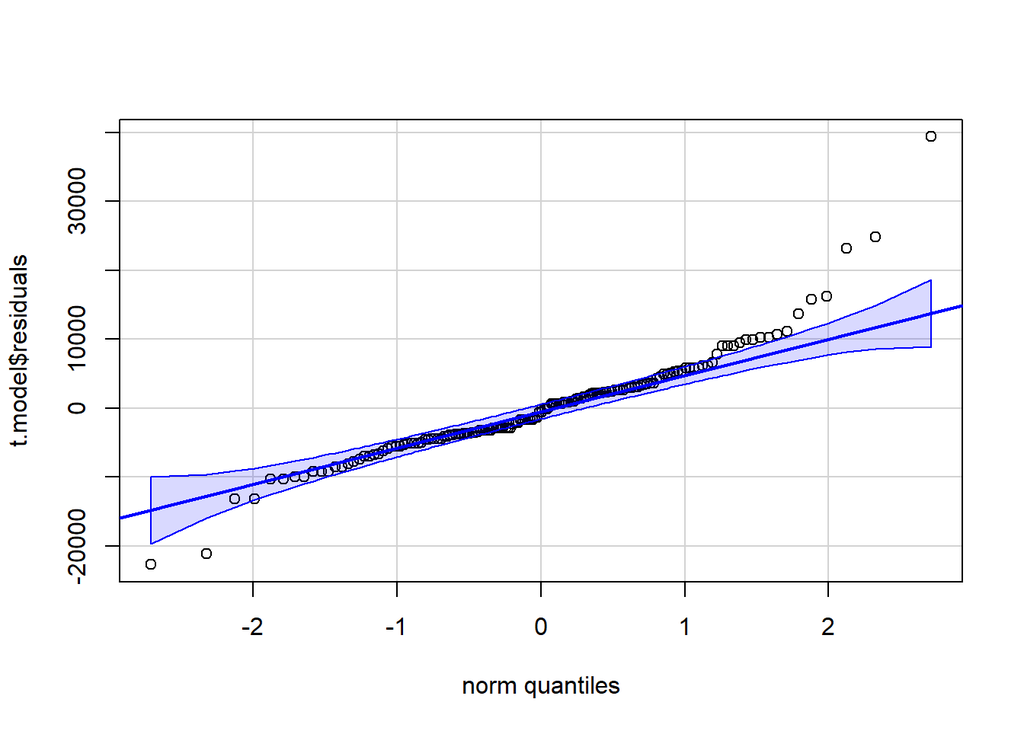

## Plot variances

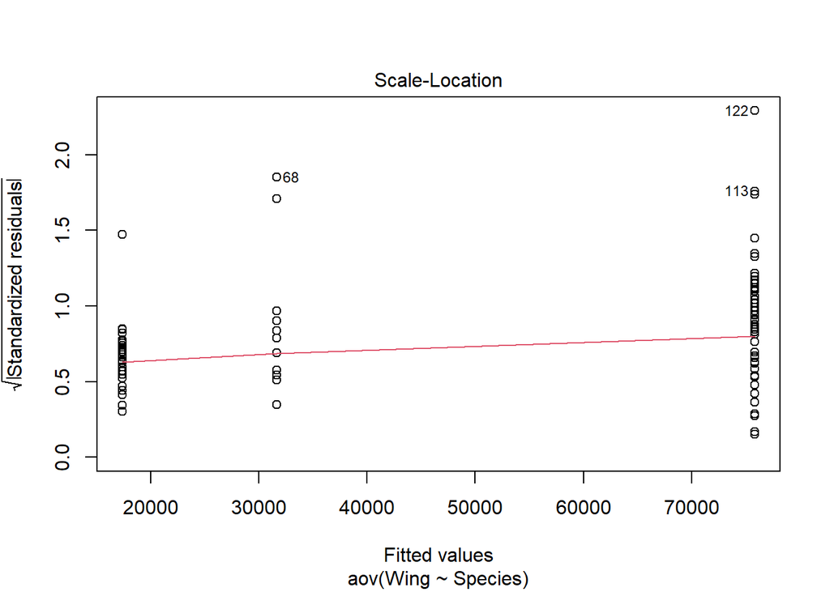

## Test for const variance

|  | Df | F value | Pr(>F) |
| --- | --- | --- | --- |
| group | 2 | 3.962041 | 0.0210903 |
|  | 147 | NA | NA |

# No outlier removal, SW Transformation

```
##              Df    Sum Sq   Mean Sq F value Pr(>F)
## Species       2 209280775 104640388    1113 <2e-16 ***
## Residuals   147  13820960     94020
## ---
## Signif. codes:  0 '***' 0.001 '**' 0.01 '*' 0.05 '.' 0.1 ' ' 1
```

## Get QQ Plot

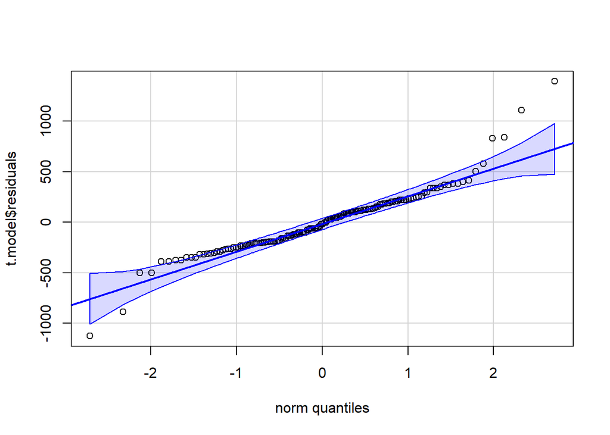

## Plot variances

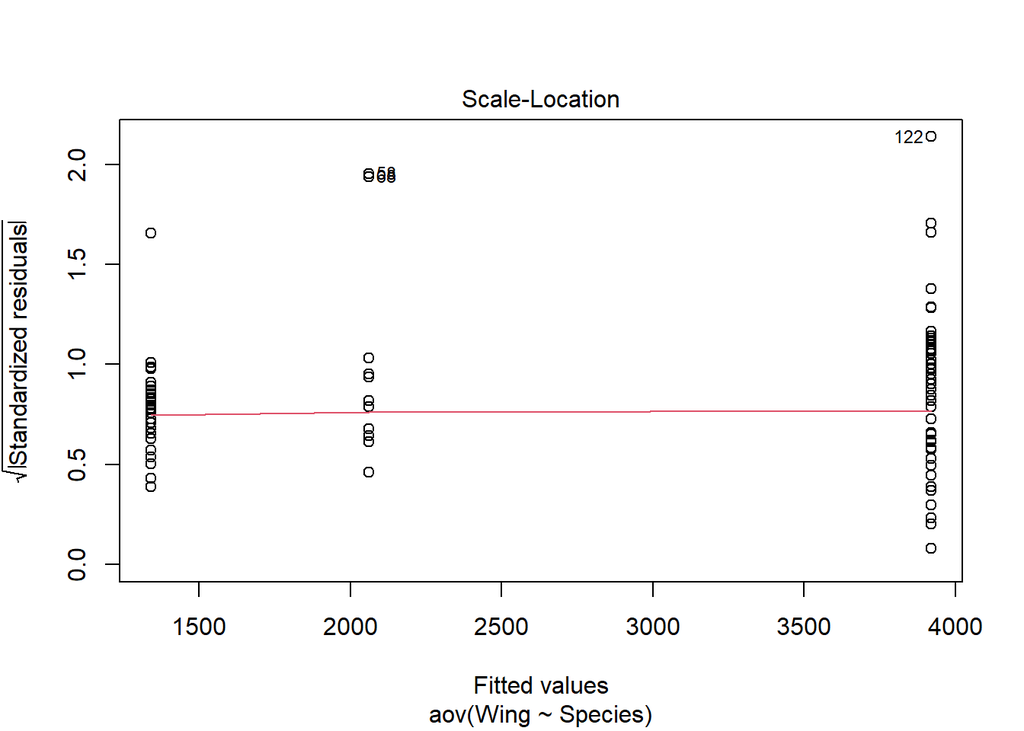

## Test for const variance

|  | Df | F value | Pr(>F) |
| --- | --- | --- | --- |
| group | 2 | 1.609378 | 0.2035159 |
|  | 147 | NA | NA |

# Possible outlier removal techniques

# Removing outliers via box plot (1)

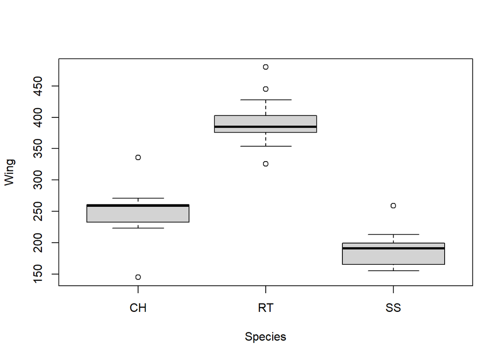

```
##              Df  Sum Sq Mean Sq F value Pr(>F)
## Species       2 1254230  627115    2141 <2e-16 ***
## Residuals   140   41013     293
## ---
## Signif. codes:  0 '***' 0.001 '**' 0.01 '*' 0.05 '.' 0.1 ' ' 1
```

## Get QQ Plot

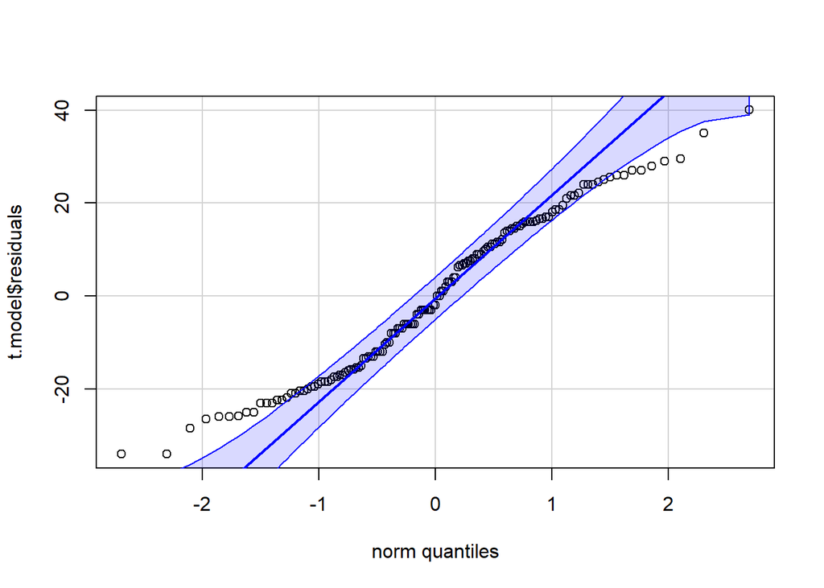

## Test for normality

```
##
##  Shapiro-Wilk normality test
##
## data:  t.model$residuals
## W = 0.96964, p-value = 0.002881
```

## Plot variances

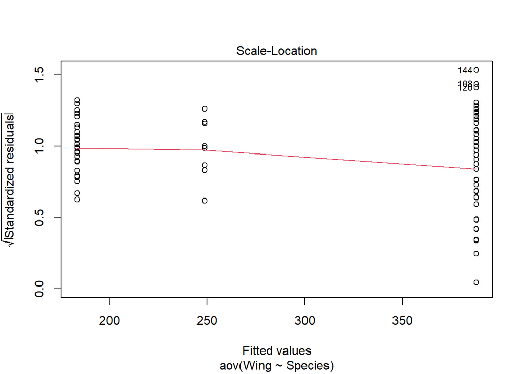

## Test for const variance

|  | Df | F value | Pr(>F) |
| --- | --- | --- | --- |
| group | 2 | 1.037341 | 0.3571034 |
|  | 140 | NA | NA |